# Assignment 10 key

```python
import numpy as np
import matplotlib.pyplot as plt
import xarray as xr
%matplotlib notebook
```

Consider a two-layer flow, hydrostatic, with an upper layer that has a resting thickness $d_1=4$ and density $\rho_1=1000$, and a lower layer with resting thickness $d_2=6$ and density $\rho_2=1010$.

As an initial condition, suppose the upper interface is flat, and the interface between the two layers is deformed as a sine wave with amplitude $\eta_0=0.1 m$, wavelength $k_0$. The fluid is otherwise at rest (i.e. $u(t=0)=0$). The displacement is small enough that the wave satisfies the linear constraint.

## Q1

1. There are four waves possible, what are their phase speeds and directions?

### Answer:

There will be two waves propagating to the left, and two to the right. One wave in each direction will be the surface wave with \begin{equation} c_S^2 = \frac{\omega_S^2}{k^2} = \frac{gH}{2}\left( 1+ \sqrt{1 - \frac{4g'd_1 d_2}{gH^2}}\right) \end{equation} and two interfacial waves with

\begin{equation} c_I^2 = \frac{\omega_I^2}{k^2} = \frac{gH}{2}\left( 1 - \sqrt{1 - \frac{4g'd_1 d_2}{gH^2}}\right) \end{equation}

```python
d1 = 4
d2 = 6
rho1=1000
rho2=1010
H = d1+d2
g = 9.8
gp = g * (rho2 - rho1) / rho2
cssq = (g * H)/2 *(1 + np.sqrt(1 - (4*gp*d1*d2)/g/H**2))

cssqA = g * H


cIsq = (g * H)/2 *(1 - np.sqrt(1 - (4*gp*d1*d2)/g/H**2))
cIsqA = gp * d1 *d2 / H


print(f'Surface: {np.sqrt(cssq):1.3f} [m/s], approx: {np.sqrt(cssqA):1.3f} [m/s]')
print(f'Interface: {np.sqrt(cIsq):1.3f} [m/s], approx: {np.sqrt(cIsqA):1.3f} [m/s]')
```

```
Surface: 9.888 [m/s], approx: 9.899 [m/s]
Interface: 0.483 [m/s], approx: 0.483 [m/s]
```

So, we can see that the approximation is good.

## Q2:

1. What is the amplitude of the surface displacement and interface displacement for each wave?

### Answer

The sea surface consists of four waves, two baroclinic and two barotropic, one of each going in each direction:

\begin{equation} \eta = A e^{i(kx - \omega_S t)} + B e^{i(kx + \omega_S t)} + C e^{i(kx - \omega_I t)} + D e^{i(kx + \omega_I t)} \end{equation}

where $k=k_0$, and $\omega_S$ and $\omega_I$ are the frequencies of surface and interfacial waves respectively.

From the initial condition for the sea surface, we have \begin{equation} A + B + C + D = \eta_0 = 0 \end{equation} where $\eta_0$ is the intial amplitude, which in this case is 0.

In class we showed the relationship between the surface displacements and the interface displacements leading to: \begin{equation} \zeta = \left(A e^{i(kx - \omega_S t)} + B e^{i(kx + \omega_S t)} \right) \left( 1 - \frac{d_1}{H} \right) + \left(C e^{i(kx - \omega_I t)} + D e^{i(kx + \omega_I t)}\right) \left(1 - \frac{g H}{g'd_2} \right) \end{equation}

So, at $t=0$:

\begin{equation} \zeta_0 = \left(A + B \right) \left( 1 - \frac{d_1}{H} \right) + \left(C + D\right) \left(1 - \frac{g H}{g'd_2} \right) \end{equation}

Finally, we can assume that $A=B$ and $C=D$ because there is no flow at time = 0.

Therefore using the above expression shows $2A = -2C$. That simplifies matters substantially and after some algebra we can show:

\begin{eqnarray} A = \frac{\zeta_0}{2} \left[ \frac{g'Hd_2}{ gH^2- g'd_2d_1}\right] \end{eqnarray}

```python
zeta = 0.1
A = zeta / 2 * (gp*H*d2)/(-gp*d2*d1+ g*H**2)
C = -A

interA = A * (1 - d1/H)

interC = C * (1 - g*H/gp/d2)

print(f'A/C: {A:0.6f} m')

print(f'Interface C {interC:0.6f} m')

print(f'Interface A {interA:0.6f} m')
```

```
A/C: 0.000298 m
Interface C 0.049821 m
Interface A 0.000179 m
```

#### NOTE:

A lot of folks assumed just two waves, and did not note that this was impossible if $u=0$ at $t=0$. If $u=0$ at $t=0$ and the interfaces are displaced, then signals propagate both to the right and left. Which was interesting because most of you drew two waves in your Hovmoller diagrams.

## Q3

1. Plot a Hovmoller diagram of the surface displacement and interface displacement covering a few wavelengths and periods. Identify the surface and interface waves in the diagram.

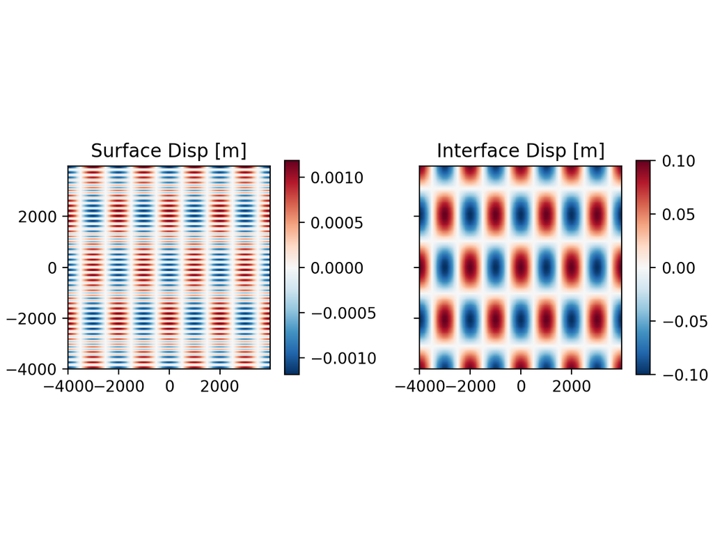

```python
k0 = np.pi * 2 / 2000
omS = np.sqrt(cssq) * k0

omI = np.sqrt(cIsq) * k0

x = np.arange(-4000, 4000, 20)
t = np.arange(-4000, 4000, 20)
X, T = np.meshgrid(x, t)
eta = A * (np.exp(1j * (k0*X - omS * T)) + np.exp(1j * (k0*X + omS * T)))  - A * (np.exp(1j * (k0*X - omI * T)) + np.exp(1j * (k0*X + omI * T)))

zeta = interA * (np.exp(1j * (k0*X - omS * T)) + np.exp(1j * (k0*X + omS * T)))  + interC * (np.exp(1j * (k0*X - omI * T)) + np.exp(1j * (k0*X + omI * T)))


fig, ax = plt.subplots(1, 2, sharex=True, sharey=True, constrained_layout=True)
pc = ax[0].pcolormesh(x, t, np.real(eta), cmap='RdBu_r')
ax[0].set_aspect(1)
ax[0].set_title('Surface Disp [m]')
fig.colorbar(pc, ax=ax[0], shrink=0.4)
pc = ax[1].pcolormesh(x, t, np.real(zeta),  cmap='RdBu_r')
ax[1].set_aspect(1)
ax[1].set_title('Interface Disp [m]')

fig.colorbar(pc, ax=ax[1], shrink=0.4)
```

So the response is two sets of standing waves, one dominated by the interface with a long period given by $\omega_I$ and the other with a short period given by $\omega_S$. Note that the surface oscilates, even though it was initially flat, because it caries the impression of the interface from below. The surface mode has only an indistinguishable influence on the interface depth.

## Q4

1. What is the energy flux of each wave?

### Answer

Energy flux is $\int u p' dz$, where $p'$ is the deviation from the background density where the layers are flat. In layer 1 $p'_1 = \rho g \eta$ and in layer 2 $p'_2 = \rho g \eta + \rho g' \zeta$. Velocity is derived from $\frac{\partial u}{\partial t} = \frac{1}{\rho}\frac{\partial p}{\partial x}$, yielding $u_1 = \frac{g}{c} \eta$ and $u_2 = \frac{g}{c} \eta + \frac{g'}{c}\zeta$.

The variables are constant in each layer so:

$F = d_1 u_1 p'_1 + d_2 u_2 p'_2$

Therefore the energy flux is \begin{eqnarray} F = \frac{g^2 H}{c} \eta^2 + d_2\frac{\zeta g'}{c}\left( \zeta g' + 2 g \eta \right) \end{eqnarray} where $c$ is the phase speed of each of the individual waves. We have all this information from above, so we can calculate the barotropic and baroclinic energy flux (in each direction)

```python
# Barotropic:
F = g**2 * H / np.sqrt(cssq) * A**2 + d2*gp/np.sqrt(cssq) * (interA**2*gp + 2*g*A*interA)
F = F/2 # average sin^2 over a period
print(f'Barotropic energy flux: {F:1.2e}')

Fbc = g**2 * H / np.sqrt(cIsq) * C**2
Fbc += d2*gp/np.sqrt(cIsq) * (interC**2*gp + 2*g*C*interC)
Fbc = Fbc/2 # average sin^2 over a period
print(f'Baroclinic energy flux: {Fbc:1.2e}')
print(f'Ratio BC/BT {(Fbc/F):1.2f}')
```

```
Barotropic energy flux: 4.34e-06
Baroclinic energy flux: 5.80e-05
Ratio BC/BT 13.39
```

So, note that the baroclinic flux substantially dominates the barotropic.

These are a little easier to interpret if we make the approximations: For the surface waves $c^2\approx gH$ and the second term is small comared to the first so \begin{eqnarray} F \approx \frac{1}{2}c g <\eta>^2 \end{eqnarray}

For the interfacial waves note $\zeta \approx \frac{-gH}{g'd_2}\eta$. Using this in the expression for $F$ above yields:

\begin{eqnarray} F & \approx & \frac{1}{2}\frac{\zeta_0^2 d_2}{cH}\left( g'^2d_2 + g'^2 H - 2g'^2d_2\right)\\ & = & \frac{1}{2}\zeta_0^2 g'^2 \frac{d_2}{Hc}\left(H - d_2\right)\\ & = & \frac{1}{2}c g'\zeta_0^2 \end{eqnarray}

```python
F = np.sqrt(g*H)*g * A**2
F = F/2 # average sin^2 over a period
print(f'Barotropic energy flux: {F:1.2e}')

Fbc = np.sqrt(cIsq) *gp * interC**2

Fbc = Fbc/2

#Fbc = d2*gp/np.sqrt(cIsq) * (interC**2*gp + 2*g*C*interC)
print(f'Baroclinic energy flux: {Fbc:1.2e}')
print(f'Ratio BC/BT {(Fbc/F):1.2f}')
```

```
Barotropic energy flux: 4.30e-06
Baroclinic energy flux: 5.82e-05
Ratio BC/BT 13.53
```

#### Notes:

Some folks seemed to think that the surface wave was $\eta$ and the interface wave was just seen on $\zeta$. This is not true - the baroclinic wave has a sea-surface expression, and the barotropic wave displaces both the surface and the interface between the layers.